# 02 — Spatial contraction metrics and choice of response variable

Eleven candidate metrics, PCA, and the justification for section occupancy (Supplementary Table S6)

Sarah Ohayon, Jacob T. Dingwall, Amanda E. Bates

2026-09-15

Before modelling we verify that **section occupancy is a representative measure of spatial contraction**, rather than one arbitrary choice among many. Eleven established metrics of the annual spawning distribution are computed from the same per-site annual maxima built in `01`, spanning two conceptually distinct families:

- **extent** — how much of the Strait spawning covers;
- **concentration** — how evenly biomass is divided among the areas that are used.

A PCA of the standardised metrics separates the two families, and the loadings on the dominant axis identify which metrics carry the shared contraction signal. This chunk produces **Supplementary Table S6**.

```r
site_year <- read_csv(file.path(DERIVED, "site_year_spawn.csv"), show_col_types = FALSE)
sy        <- read_csv(file.path(DERIVED, "section_year.csv"),   show_col_types = FALSE)
annual    <- read_csv(file.path(DERIVED, "annual_series.csv"),  show_col_types = FALSE)

## mean coordinates per location and per section
loc_xy <- site_year %>% group_by(LocationCode) %>%
  summarise(lon = mean(Longitude, na.rm = TRUE), lat = mean(Latitude, na.rm = TRUE),
            .groups = "drop")
sec_xy <- site_year %>% group_by(Section) %>%
  summarise(lon = mean(Longitude, na.rm = TRUE), lat = mean(Latitude, na.rm = TRUE),
            .groups = "drop")

site_xy <- site_year %>% left_join(loc_xy, by = "LocationCode")
syx     <- sy        %>% left_join(sec_xy, by = "Section")
```

## 1 Location-level metrics

Kernel utilisation areas (50% and 95%) use a reference bandwidth and are clipped to water, so that a distribution hugging a coastline is not credited with area over land. Convex-hull area and latitudinal range are the two simplest extent measures.

```r
water_sog <- tryCatch({
  land <- ne_states(country = c("Canada","United States of America"),
                    returnclass = "sf") %>% st_transform(3005)
  bb <- st_bbox(c(xmin = -125.5, xmax = -122.5, ymin = 48.2, ymax = 50.5),
                crs = st_crs(4326)) %>% st_as_sfc() %>% st_transform(3005)
  st_difference(bb, st_union(land))
}, error = function(e) NULL)

## every site_year row is a recorded spawn (presence), with or without a biomass estimate
pts <- site_xy %>%
  st_as_sf(coords = c("lon","lat"), crs = 4326) %>% st_transform(3005)

kde <- pts %>% group_split(Year) %>% map_df(function(.x) {
  yr <- unique(.x$Year)
  if (nrow(.x) < 5) return(tibble(Year = yr, kde50_km2 = NA_real_, kde95_km2 = NA_real_))
  kd <- tryCatch(kernelUD(as(.x, "Spatial"), h = "href"), error = function(e) NULL)
  ar <- function(p) {
    v <- tryCatch(getverticeshr(kd, percent = p), error = function(e) NULL)
    if (is.null(v)) return(NA_real_)
    vs <- st_as_sf(v)
    if (!is.null(water_sog)) vs <- tryCatch(st_intersection(vs, water_sog), error = function(e) vs)
    if (nrow(vs) == 0) NA_real_ else sum(as.numeric(st_area(vs)))/1e6
  }
  tibble(Year = yr,
         kde50_km2 = if (is.null(kd)) NA_real_ else ar(50),
         kde95_km2 = if (is.null(kd)) NA_real_ else ar(95))
})

hull <- pts %>% group_by(Year) %>% summarise(g = st_union(geometry), .groups = "drop") %>%
  mutate(hull_area_km2 = as.numeric(st_area(st_convex_hull(g)))/1e6) %>%
  st_drop_geometry() %>% select(Year, hull_area_km2)

latr <- site_xy %>% group_by(Year) %>%
  summarise(lat_range = max(lat, na.rm = TRUE) - min(lat, na.rm = TRUE), .groups = "drop")
```

## 2 Section-level metrics

```r
f_core <- function(df, f = .25) {
  df <- df %>% filter(biomass > 0) %>% arrange(desc(biomass))
  if (!nrow(df)) return(NA_real_)
  k <- max(1, ceiling(f*nrow(df))); sum(df$biomass[1:k])/sum(df$biomass)
}
f_mpd <- function(df) {
  df <- df %>% filter(spawned) %>% drop_na(lon, lat)
  if (nrow(df) < 2) return(NA_real_)
  Dm <- distm(df[, c("lon","lat")], fun = distHaversine)/1000
  mean(Dm[upper.tri(Dm)], na.rm = TRUE)
}
f_disp <- function(df) {
  df <- df %>% filter(biomass > 0) %>% drop_na(lon, lat)
  if (!nrow(df)) return(NA_real_)
  w  <- df$biomass; cx <- weighted.mean(df$lon, w); cy <- weighted.mean(df$lat, w)
  d  <- distHaversine(df[, c("lon","lat")], c(cx, cy))/1000
  mu <- weighted.mean(d, w); sqrt(weighted.mean((d - mu)^2, w))
}
f_mor <- function(df, k = 4) {
  df <- df %>% drop_na(lon, lat)
  if (nrow(df) < (k + 2)) return(NA_real_)
  knn <- knearneigh(as.matrix(df[, c("lon","lat")]), k = k)
  lw  <- nb2listw(knn2nb(knn), style = "W", zero.policy = TRUE)
  unname(moran.test(df$biomass, lw, zero.policy = TRUE)$estimate[["Moran I statistic"]])
}

## long-term biomass centroid, for the edge-radius metric
hc <- syx %>% filter(biomass > 0) %>% drop_na(lon, lat) %>%
  summarise(hx = weighted.mean(lon, biomass), hy = weighted.mean(lat, biomass))

sec_m <- syx %>% group_by(Year) %>% group_modify(~ tibble(
  core25           = f_core(.x),
  gini             = ineq::Gini(.x$biomass),
  mean_pairwise_km = f_mpd(.x),
  sd_dist_km       = f_disp(.x),
  moranI           = f_mor(.x),
  edge_radius_km   = {
    d <- .x %>% filter(spawned) %>% drop_na(lon, lat)
    if (!nrow(d)) NA_real_ else max(distHaversine(d[, c("lon","lat")], c(hc$hx, hc$hy))/1000)
  })) %>% ungroup()

metrics_all <- reduce(list(annual %>% select(Year, occupancy), kde, hull, latr, sec_m),
                      left_join, by = "Year") %>% arrange(Year)
write_csv(metrics_all, file.path(DERIVED, "contraction_metrics_ALL.csv"))
glimpse(metrics_all)
```

```
## Rows: 74
## Columns: 12
## $ Year             <dbl> 1951, 1952, 1953, 1954, 1955, 1956, 1957, 1958, 1959,…
## $ occupancy        <dbl> 0.6842105, 0.6315789, 0.4736842, 0.5789474, 0.7368421…
## $ kde50_km2        <dbl> 5347.699, 4566.156, 3665.279, 3672.223, 4913.444, 452…
## $ kde95_km2        <dbl> 12156.662, 10598.350, 9506.502, 9314.079, 11225.620, …
## $ hull_area_km2    <dbl> 8947.609, 9030.066, 6730.156, 6507.568, 9376.256, 901…
## $ lat_range        <dbl> 1.812500, 1.765388, 1.487500, 1.442500, 1.765388, 1.6…
## $ core25           <dbl> 0.9633207, 0.8397822, 0.8106068, 0.8738818, 0.8030816…
## $ gini             <dbl> 0.8975389, 0.8297747, 0.8024957, 0.8358500, 0.7509718…
## $ mean_pairwise_km <dbl> 100.42856, 93.91558, 79.52128, 79.82864, 89.38920, 94…
## $ sd_dist_km       <dbl> 20.15297, 24.13288, 18.68882, 15.18014, 22.51749, 25.…
## $ moranI           <dbl> -0.0618737843, 0.1569756900, 0.0581787190, -0.0655447…
## $ edge_radius_km   <dbl> 141.2436, 123.9112, 109.1197, 109.1197, 123.9112, 123…
```

## 3 PCA and correlations — Supplementary Table S6

```r
mcols <- c("occupancy","kde50_km2","kde95_km2","hull_area_km2","lat_range",
           "mean_pairwise_km","sd_dist_km","edge_radius_km","core25","gini","moranI")
dd <- metrics_all %>% select(all_of(mcols)) %>% drop_na()
pc <- prcomp(scale(dd))

var_pc <- summary(pc)$importance[2, ]
cat(sprintf("PC1 = %.0f%% of variance, PC2 = %.0f%% (n = %d complete years)\n",
            100*var_pc[1], 100*var_pc[2], nrow(dd)))
```

```
## PC1 = 62% of variance, PC2 = 16% (n = 74 complete years)
```

```r
metric_labels <- c(
  occupancy        = "Section occupancy",
  kde50_km2        = "50% kernel utilisation area",
  kde95_km2        = "95% kernel utilisation area",
  hull_area_km2    = "Convex-hull area",
  lat_range        = "Latitudinal range",
  mean_pairwise_km = "Mean pairwise distance among sections",
  sd_dist_km       = "Centroid dispersion",
  edge_radius_km   = "Edge radius",
  core25           = "Core concentration (top 25% of sections)",
  gini             = "Gini coefficient of section biomass",
  moranI           = "Moran's I of section biomass")

metric_family <- c(rep("Extent", 8), rep("Concentration", 3))
names(metric_family) <- c("occupancy","kde50_km2","kde95_km2","hull_area_km2","lat_range",
                          "mean_pairwise_km","sd_dist_km","edge_radius_km",
                          "core25","gini","moranI")

tabS6 <- tibble(
  metric       = mcols,
  Metric       = metric_labels[mcols],
  Family       = metric_family[mcols],
  PC1_loading  = round(abs(pc$rotation[, 1]), 2),
  PC2_loading  = round(abs(pc$rotation[, 2]), 2),
  r_with_occupancy = round(sapply(mcols, function(m) cor(dd[[m]], dd$occupancy)), 2)) %>%
  arrange(desc(PC1_loading)) %>% select(-metric)

save_tab(tabS6, "TableS6_contraction_metric_loadings")
kable(tabS6, caption = sprintf(
  "Supplementary Table S6. Contraction metrics: absolute PC1 and PC2 loadings and correlation with section occupancy (n = %d years). PC1 explains %.0f%% of variance and PC2 %.0f%%.",
  nrow(dd), 100*var_pc[1], 100*var_pc[2]))
```

Supplementary Table S6. Contraction metrics: absolute PC1 and PC2 loadings and correlation with section occupancy (n = 74 years). PC1 explains 62% of variance and PC2 16%.

| Metric | Family | PC1_loading | PC2_loading | r_with_occupancy |
| --- | --- | --- | --- | --- |
| 95% kernel utilisation area | Extent | 0.37 | 0.01 | 0.83 |
| Section occupancy | Extent | 0.35 | 0.12 | 1.00 |
| 50% kernel utilisation area | Extent | 0.35 | 0.11 | 0.87 |
| Latitudinal range | Extent | 0.35 | 0.12 | 0.77 |
| Convex-hull area | Extent | 0.34 | 0.05 | 0.91 |
| Mean pairwise distance among sections | Extent | 0.31 | 0.25 | 0.60 |
| Edge radius | Extent | 0.31 | 0.27 | 0.61 |
| Centroid dispersion | Extent | 0.30 | 0.15 | 0.66 |
| Gini coefficient of section biomass | Concentration | 0.26 | 0.52 | -0.74 |
| Moran’s I of section biomass | Concentration | 0.18 | 0.24 | -0.37 |
| Core concentration (top 25% of sections) | Concentration | 0.03 | 0.69 | 0.03 |

```r
occ_r <- tabS6$r_with_occupancy[tabS6$Metric == "Section occupancy"]
ext_r <- tabS6 %>% filter(Family == "Extent", Metric != "Section occupancy") %>%
  pull(r_with_occupancy)
cat(sprintf("Occupancy PC1 loading = %.2f (rank %d of %d)\n",
            tabS6$PC1_loading[tabS6$Metric == "Section occupancy"],
            which(tabS6$Metric == "Section occupancy"), nrow(tabS6)))
```

```
## Occupancy PC1 loading = 0.35 (rank 2 of 11)
```

```r
cat(sprintf("Correlation of occupancy with the other extent metrics: r = %.2f to %.2f\n",
            min(ext_r), max(ext_r)))
```

```
## Correlation of occupancy with the other extent metrics: r = 0.60 to 0.91
```

```r
cat(sprintf("Correlation of occupancy with the Gini coefficient: r = %.2f\n",
            tabS6$r_with_occupancy[tabS6$Metric == "Gini coefficient of section biomass"]))
```

```
## Correlation of occupancy with the Gini coefficient: r = -0.74
```

**Why occupancy.** It loads among the highest metrics on the dominant contraction axis, so it carries the shared signal rather than an idiosyncratic one; it is the most directly interpretable, as the loss of discrete spawning grounds; and it is the most robust to survey effort, being a bounded proportion computed from presence rather than from index magnitude. Occupancy is identical whether location-years are reduced to their maximum or summed, and it is unaffected by any rescaling of index magnitude — the property exploited in `03`.

## 4 Metric trajectories (diagnostic, not a manuscript figure)

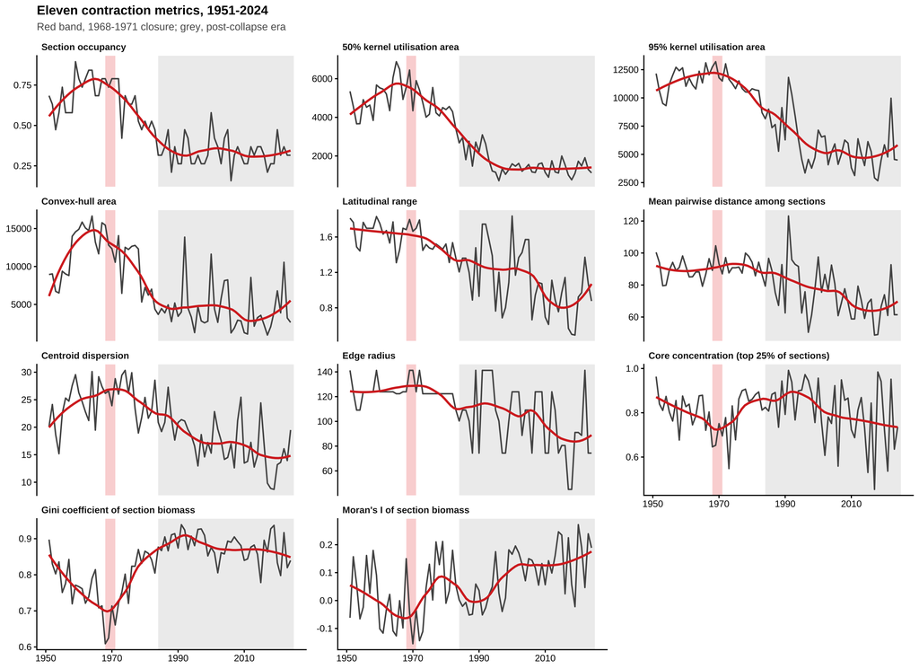

```r
metrics_all %>%
  pivot_longer(-Year, names_to = "metric", values_to = "value") %>%
  mutate(metric = factor(metric_labels[metric], levels = unname(metric_labels))) %>%
  filter(!is.na(value)) %>%
  ggplot(aes(Year, value)) +
  band_postcoll() + band_closure() +
  geom_line(colour = col_occ, linewidth = 0.6) +
  geom_smooth(method = "loess", span = 0.4, se = FALSE, colour = col_old, linewidth = 0.9) +
  facet_wrap(~metric, scales = "free_y", ncol = 3) +
  labs(x = NULL, y = NULL,
       title = "Eleven contraction metrics, 1951-2024",
       subtitle = "Red band, 1968-1971 closure; grey, post-collapse era") +
  theme_herring(10)
```